# Predicting Locational Marginal Electricity Prices in Goleta using Machine Learning

Jaxon Stuhr

2022-11-18

# Background

## Introduction

Local weather has always been a significant driver of electricity consumption, leading to increased heating or cooling to provide comfort from extreme temperatures. Additionally, as an ever-growing share of California’s electricity is produced from renewable sources (solar + wind), the weather has begun to influence how our energy is produced as well. Balancing the supply and demand of electricity at any given time is crucial to maintaining a stable grid, however, non-renewable forms of generation often have large startup times and significant costs associated with their labor and fuel consumption. For these reasons it is immensely important to forecast both electricity supply and demand accurately at any given time at different locations throughout the State, as transmission capacity also can severely limit electricity transfer from one are to another.

This relationship between spatio-temporal supply and demand is evidenced in what are called “Locational Marginal Prices” (LMPs). These are wholesale electricity prices, unique to over 5000 nodes in California, that are driven by a combination of local demand, supply, and transmission capacity. I was curious how well simple machine-learning algorithms learned in this class could do at predicting these LMPs when paired with both 1) historical LMP data and 2) NOAA weather data.

## Data Procurement

The first challenged I faced was developing datasets of 1) LMPs for all Nodes in California for the years 2019 - 2022 (at an hourly time-scale) and 2) Weather data for all locations in CA for (also for the years 2019-2022 at an hourly time-scale). Luckily I was put in tough with Guillermo Terren Serrano, a postdoc in Ranjit Deshmuk’s CETLab at UCSB. Guille had written APIs to pull LMP data from CAISO’s website and weather data from NOAA’s website. He hadn’t yet been able to take advantage of it yet, however, because CAISO does not publish the locations of the nodes (essentially, when one downloads the data, the data file includes *node IDs* and *LMPs*, but not the *latitude* and *longitude* associated with the *node ID)*. I was able to write a script that scraped a CAISO Map’s HTML to create a crosswalk of Node IDs and node locations (lat and lon). I won’t, however, be sharing the script or the Node locations as we are hoping to publish an expanded version of this work in the near future, and finding these node locations seems to be in demand. I have included a Map I made of all node locations below. Using the Node location crosswalk along with Guille’s APIs, we were able to create complete datasets of NOAA weather history (15 weather parameters at 9152 locations for 3 years, hourly) and LMPs (price for over 5000 locations for 3 years, hourly).

## Scope

Due to time and memory limitations, this analysis will focus on predicting LMPs for a single node, rather than all nodes in CA. We plan on expanding the analysis to be able to forecast electricity prices for the entire state, however, each node will have its own unique combination of predictors (parameters and locations), so the models will need to be run independently for each node.

We chose to focus on local prices, choosing the node GOLETA_6_N200 with latitude and longitude: (34.4688 -119.8844) Additionally, we included only a subset of the weather data for our model. This will be expanded upon in the *methods* section.

## Model Performance

Performance of electricity forecasting models is typically compared to what’s known as a *persistence* model. The *persistence* model follows the simple equation:

$$LMP_{day, hour} = LMP_{day-1, hour}$$

Assuming the LMP of a given day and hour is simply yesterday’s price at that same hour. This is used often for electricity forecasting because the *day ahead* market’s are projected 24 hours in advance, meaning that $LMP_{day-1, hour}$ data is available when market’s (and electricity generation dispatch) is being planned.

The key performance indicator for a model such as this is the *forecasting skill*, $\alpha$:

$$\alpha = 1-\frac{RMSE_{model}}{RMSE_{persistence}}$$

Thus a model with an $RMSE$ equal to that of the persistence model would score $0$, and a model with an $RMSE$ of $0$ would score $1$. $\alpha <0$ should not occur as $LMP_{day-1, hour}$ is included as a parameter in the model, so if the model cannot gain any predictive power from the weather data, it would include only $LMP_{day-1, hour}$ and score $\alpha = 0$.

# Data

## Raw Data

The first challenge was getting all of the data into R dataframes formatted such that *tidymodels* would be able to interpret it. Guille’s scripts were in python so I was provided with .pkl files of LMPS and NOAA actual hourly weather data for three years.

$$3\:years\:*\:365\:days/year\:*\:24\:hrs/day\:=\:26280\:observations$$

For each hour, NOAA provides data for >9000 locations in and around CA on 15 weather parameters (all numeric) summarized in Table 1 below:

Table 1: NOAA Weather Parameters

| Parameter | ID | Unit |
| --- | --- | --- |
| Pressure | PRES | pa |
| Direct Solar Irradiance | DSWRF | W/m2 |
| Diffuse Solar Irradiance | DLWRF | W/m2 |
| Dew Point (2m) | DPT_2m | K |
| Relative Humidity (2m) | RH_2m | % |
| Temperature (2m) | TMP_2m | K |
| Wind Speed (10m) | WS_10m | m/s |
| Wind Speed (60m) | WS_60m | m/s |
| Wind Speed (80m) | WS_80m | m/s |
| Wind Speed (100m) | WS_100m | m/s |
| Wind Speed (120m) | WS_120m | m/s |
| Discomfort Index (2m) | DI_2m | % |
| Wind Chill (2m) | WC_2m | K |
| Heating Cooling Degree Hour (2m) | HCDH_2m | K |
| (unknown) | GSI | (unknown) |

$$15\:parameters\:*\:9152\:locations\:=\:137280\:potential \:predictors$$

## Filtering

My hope was to run a LASSO on all 137280 predictive parameters, however, R’s memory couldn’t handle this. I am still working on figuring out a way to include more parameters, but to be able to carry on with the analysis, I filtered the dataset in two ways:

1. I eliminated weather observations from alternating nodes in both the X and Y directions, effectively filtering out 75% of locations
2. I only considered weather observations with a radius $r<r_0$ . I am currently setting up functionality to perform cross validation over a range of $r_0$, however, for this analysis $r_0 = 1.5\: degrees \approx 100\: miles$

This filtering left me with 1695 predictors (113 locations x 15 parameters). The following code chunks carry out the data cleaning and filtering described above, and the map (Figure 1) shows the weather node locations that were considered in the final analyses. The latitude and longitude of the Goleta LMP Node is: (34.4688 -119.8844).

```r
# import pandas to read .pkl files into R
pd = import("pandas")
```

```r
# define paths o nmy computer to LMP, weather, and land data files
ac_lmp_files <- list.files(path="C:/Users/jzs88/Box/LMP_Predictive_Modeling/acLMPs",
                    pattern=".pkl",
                    all.files=T,
                    full.names=T)
ac_weather_files <- list.files(path="C:/Users/jzs88/Box/LMP_Predictive_Modeling/acWeather",
                    pattern=".pkl",
                    all.files=T,
                    full.names=T)
us_land_path <- "C:/Users/jzs88/Box/LMP_Predictive_Modeling/spatial_grid/USland_0.125_(-125,-112)_(32,43).pkl"
ref_grid_path <- "C:/Users/jzs88/Box/LMP_Predictive_Modeling/spatial_grid/ref_grid_0.125_(-125,-112)_(32,43).pkl"
```

```r
# initialize values for building LMP dataframe

# 5 minute bins => 12 bins per hour, assuming 0-55
lmp_minutes = 12
# build list of LMP minutes 0, 5, 10, ..., 55
lmp_minute_list = (0:11)*5
lmp_hours = 24

# start minute, hour counters at 0
minute = 0
hour = 0
# build LMP hour list of length 288 = 12 (minute bins) x 24 (hours)
lmp_hour_list = matrix(1, lmp_minutes*lmp_hours)
# iterate through list
for (i in 1:length(lmp_hour_list)) {
  # first 12 bins have hour = 0, then 1, etc up to 23
  if (minute < lmp_minutes) {
    lmp_hour_list[i] = hour
    minute = minute + 1
  } else {
    hour = hour + 1
    lmp_hour_list[i] = hour
    minute = 1
  }
}
```

```r
# write a function that returns LMPs for input lists of file paths
build_lmp_data_frame = function(file_paths) {
  # initialize LMP data frame with column labels
  lmp_data_frame = data.frame(matrix(nrow = 0, ncol = 7))
  colnames(lmp_data_frame) = c("lmp", "date", "hour", "minute", "node_id", "lat", "lon")
  # iterate through file paths
  for (lmp_file in file_paths) {
    # pull out full dataset for current path, node_id, lat, lon
    current_node_id = sub(".pkl", "", sub("C:/Users/jzs88/Box/LMP_Predictive_Modeling/acLMPs/CA_", "", lmp_file))
    # current_lat = node_locations_no_dups$lat[match(current_node_id, node_locations_no_dups$node_id)]
    # current_lon = node_locations_no_dups$lon[match(current_node_id, node_locations_no_dups$node_id)]
    # defined explicitly becuase I am no including the node_locations_crosswalk.Rmd code
    current_lat = 34.4688
    current_lon = -119.8844
    current_node_lmps = pd$read_pickle(lmp_file)
    # iterate through all days for current node
    for (i in 2:length(current_node_lmps)) {
      # pull out all data for day i
      day_data = current_node_lmps[i]
      # pull out only LMPs for day i
      lmps_list = c(day_data[[1]])
      date = ymd(names(current_node_lmps[i]))
      # build dataframe for day i LMPs
      current_day_lmps = data.frame(
        # values from current vectorized LMP list
        lmp = lmps_list,
        # date from current data
        year = year(date),
        month = month(date),
        day = day(date),
        # hour, minute from previoiusly built iterative lists
        hour = lmp_hour_list,
        minute = lmp_minute_list,
        # node id, lat, lon, consistent across entire nested for loop
        node_id = current_node_id,
        lat = current_lat,
        lon = current_lon
      )
      # bind this days data to complete data frame
      lmp_data_frame = rbind(lmp_data_frame, current_day_lmps)
    }
  }
  lmp_data_frame = lmp_data_frame %>%
    filter(minute == 0) %>%
    mutate(date = ymd_h(paste(year, month, day, hour))) %>%
    select(-c(year, month, day, hour, minute))
  # return entire LMP data frame
  return(lmp_data_frame)
}
```

```r
current_node = "GOLETA_6_N200"
# build goleta lmps data frame
goleta_lmps = build_lmp_data_frame(ac_lmp_files[4]) %>%
  filter(node_id == current_node)# %>%
# build dataframe of goleta_node lat and lon
loc_goleta = c(unique(goleta_lmps$lat), unique(goleta_lmps$lon))
# specify max radius within which to include weather observations
radius = 1.5
```

```r
# read in us_land and ref_grid from pkl files
us_land = pd$read_pickle(us_land_path)
ref_grid = pd$read_pickle(ref_grid_path)

# convert entire grid to data frame
ref_grid = as.data.frame(ref_grid) %>%
  rename(lon = V1,
         lat = V2)

#initialize us grid
us_grid = ref_grid %>%
  mutate(land = 0)

# label and filter for only points on land
us_grid$land[1:length(us_grid$land)] = us_land
us_grid = us_grid %>%
  filter(land == 1) %>%
  mutate(lat_lon = paste(as.character(lat), as.character(lon)))

locs_in_rad = ref_grid %>%
  filter((lat %% .25) == 0) %>%
  filter((lon %% .25) == 0) %>%
  #filter(paste(as.character(lat), as.character(lon)) %in% us_grid$lat_lon ) %>%
  filter( ((loc_goleta[1] - lat)^2 + (loc_goleta[2] - lon)^2)^(1/2) < radius)

mapview(locs_in_rad, xcol = "lon", ycol = "lat", crs = 4269)
```

[interactive chart not shown]

Figure 1: Map of Weather Nodes included in Analysis within ~100 miles of GOleta LMP Node

```r
# setup crosswalk of weather parameters
weather_params_ac = data.frame(
  param = c("PRES",  "DSWRF", "DLWRF", "DPT_2m", "RH_2m", "TMP_2m", "WS_10m", "WS_60m", "WS_80m", "WS_100m", "WS_120m", "DI_2m", "WC_2m", "HCDH_2m", "GSI"),
  unit = c("pa", "W/m2", "W/m2", "K", "%", "K", "m/s", "m/s", "m/s", "m/s", "m/s", "?", "K?", "degree_hour", "?")
)

hours = 24
params = 15
locs = 9152

# build list of hours that is length 24 (hrs)
hours_list = 0:23

# build list of parameters that is length 24 (hrs) x 15 (parameters)
hour = 0
param_index = 1
params_list = matrix(1, hours*params)
for (i in 1:length(params_list)) {
  if (hour < hours) {
    params_list[i] = weather_params_ac$param[param_index]
    hour = hour + 1
  } else {
    param_index = param_index + 1
    params_list[i] = weather_params_ac$param[param_index]
    hour = 1
  }
}

# build lists of lats and lons that are length 24 (hrs) x 15 (parameters) x 9152 (locations)
hour_params = 0
loc_index = 1
lat_list = matrix(1, hours*params*locs)
lon_list = matrix(1, hours*params*locs)
for (i in 1:length(lat_list)) {
  if (hour_params < hours*params) {
    lat_list[i] = ref_grid$lat[loc_index]
    lon_list[i] = ref_grid$lon[loc_index]
    hour_params = hour_params + 1
  } else {
    loc_index = loc_index + 1
    lat_list[i] = ref_grid$lat[loc_index]
    lon_list[i] = ref_grid$lon[loc_index]
    hour_params = 1
  }
}
```

```r
# create function to build dataframe from list of files paths, list of dates, and variable lists
build_weather_data_frame = function(file_paths) {

  # initialize complete weathere data frame
  weather_data_frame = data.frame(matrix(nrow = 0, ncol = 137284))
  colnames(weather_data_frame) = c("value", "year", "month", "day", "hour", "parameter", "lat", "lon")

  # iterate through file paths provided
  for (i in 1:length(file_paths)) {
    # print which path code is on no check run speed
    print(i)
    flush.console()
    # read in vectorized weather data from current file path
    weather_list = c(pd$read_pickle(file_paths[i]))
    date = ymd(str_sub(sub(".pkl", "", file_paths[i]), -8, -1))
    # build new data frame of current weather data
    current_weather = data.frame(
      # values from current vectorized weather list
      value = weather_list,
      year = year(date),
      month = month(date),
      day = day(date),
      # hour, parameter, lat, lon from previoiusly built iterative lists
      hour = hours_list,
      parameter = params_list,
      lat = lat_list,
      lon = lon_list
      ) %>%
      # skip every other land loc in both directions (25% of total locations)
      filter((lat %% .25) == 0) %>%
      filter((lon %% .25) == 0) %>%
      # filter out weather data for locations w/ euclidean distance > radius specified above
      filter( ((loc_goleta[1] - lat)^2 + (loc_goleta[2] - lon)^2)^(1/2) < radius) %>%
      # expand data to include an individual covariate for each parameter at each location
      pivot_wider(names_from = c(parameter, lat, lon), values_from = value, names_sep = "//")
    # append current weather data to complete data frame
    weather_data_frame = rbind(weather_data_frame, current_weather)
  }
  weather_data_frame = weather_data_frame %>%
      mutate(date = ymd_h(paste(year, month, day, hour))) %>%
      select(-c(year, month, day, hour))
  # return data frame with weather from all files and dates provided
  return(weather_data_frame)
}
```

```
# build weather data for given radius if not already saved as RDS file
weather_1 = build_weather_data_frame(ac_weather_files[1:200])
weather_2 = build_weather_data_frame(ac_weather_files[201:400])
weather_3 = build_weather_data_frame(ac_weather_files[401:600])
weather_4 = build_weather_data_frame(ac_weather_files[601:800])
weather_5 = build_weather_data_frame(ac_weather_files[801:1000])
weather_6 = build_weather_data_frame(ac_weather_files[1001:1095])
all_weather = rbind(weather_1, weather_2, weather_3, weather_4, weather_5, weather_6)

# save weather as RDS file all_weather_r_"radius"_w_"number of weather days".rds
saveRDS(all_weather, file = here("outputs", "all_weather_r_2_w_1095.rds"))
```

```
# read in weather file for radius = 0.8, first 656 weather files, every other weather location, node = goleta200
all_weather = readRDS(here("outputs", "all_weather_r_08_w_656.rds"))

# read in weather file for radius = 0.8, first 656 weather files, every other weather location, node = goleta200
all_weather = readRDS(here("outputs", "all_weather_r_1_w_1095.rds"))
```

```r
# read in weather file for radius = 1.5, every other weather location, node = goleta200
all_weather = readRDS(here("outputs", "all_weather_r_1_5_w_1095.rds"))
```

```r
# filter for only LMP data
goleta_lmps_only = goleta_lmps %>%
  filter(date %in% all_weather$date) %>%
  select(lmp, date)
# build dataset for modelling from LMP data + weather data (dates + hour should match)
all_model_data = merge(goleta_lmps_only, all_weather) %>%
  # remove extreme outliers and missing data
  filter(lmp < 200) %>%
  filter(lmp > -50) %>%
  na.exclude()
# add prev_day_lmp variable, using yesterday's LMP to predict todays
all_model_data = all_model_data %>%
  mutate(prev_day_lmp = all_model_data$lmp[match(date - days(1), all_model_data$date)]) %>%
  na.exclude()

med_lmp = median(all_model_data$lmp)
```

## Data-Splitting and Cross-Validation

Additionally, the training is “folded” three times, so that we can consider another layer of training and testing. When tuning our model parameters, each model will be trained on two of the folds, and its performance tested on the third, so as to avoid overfitting that might occur on the training data. Models that do overfit to the training data will perform worse on testing sets when being “cross-validated” and will not be selected.

Due to the extremely large amount of data and significant model tun time, I chose to split the training set into only 3 folds instead of the more typical 5.

```r
# split all_model_data into training, testing sets
goleta_split <- initial_split(all_model_data %>% select(-date), prop = .8)
goleta_train <- training(goleta_split)
goleta_test <- testing(goleta_split)
# generate folds from training data
goleta_folds <- vfold_cv(goleta_train, v = 3)
# build persistence dataset that is only yesterdays + todays LMP
```

# Exploratory Data Analysis

## LMP EDA

Figure 2b, showing mean LMPs for each hour of the day, is exactly what we expect. Prices dip during the middle of the day, when temperatures are warmer and variable generation (solar, wind) are at their maximum and then spike in the evening when people are at home consuming electricity and variable generation has dropped off. This effect was predicted in 2012 by CAISO and is called the “Duck Curve” (Figure 3).

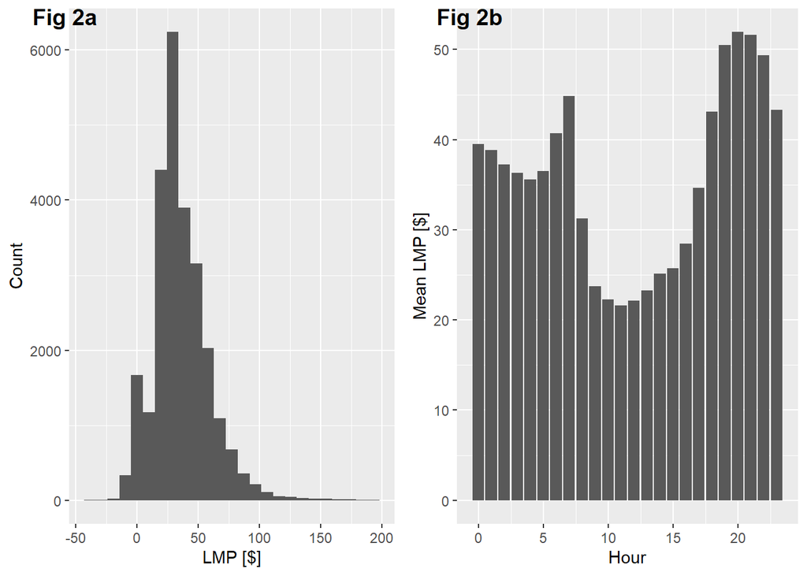

```r
# visualize LMP data, removing outliers
goleta_lmps_filtered = goleta_lmps_only %>%
  filter(lmp < 200) %>%
  filter(lmp > -50)

par(mfrow=c(1,2))

lmp_hist = ggplot(goleta_lmps_filtered, aes(x = lmp))+
  geom_histogram(bins = 25) +
  labs(x = "LMP [$]", y = "Count")

hour_summary_full = goleta_lmps_filtered %>%
  group_by(hour = hour(date)) %>%
  summarize(mean_lmp = mean(lmp))

lmp_hourly = ggplot(hour_summary_full, aes(x = hour, y = mean_lmp)) +
  geom_col(position = "dodge") +
  labs(x = "Hour", y = "Mean LMP [$]")

ggarrange(lmp_hist, lmp_hourly, labels = c("Fig 2a", "Fig 2b"))
```

```r
median(all_model_data$lmp)
```

```
## [1] 32.0278
```

Figure 2a: LMP Histogram and 2b: LMP Hourly

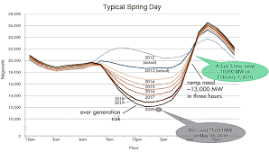

```r
knitr::include_graphics(here("images", "duck_curve.png"))
```

Figure 3: CAISO’s Duck Curve

Source: https://www.caiso.com/documents/flexibleresourceshelprenewables_fastfacts.pdf

## Weather EDA

The complete weather dataset has a unique parameter for every combination of location and weather parameters, creating 1695 predictor variables. First, I’ll perform EDA separately for just Weather Parameters, aggregating the spatial variation, looking for correlations between those 15 parameters. Then, I’ll make maps to visualize mean spatial correlations. Lastly, I’ll examine a complete correlation matrix of all 1695 predictors.

Here, I write a new function to read in weather files that does not convert locations to unique predictors.

```r
# create function to build dataframe from list of files paths, list of dates, and variable lists
build_weather_data_frame_long = function(file_paths) {

  # initialize complete weathere data frame
  weather_data_frame = data.frame(matrix(nrow = 0, ncol = 8))
  colnames(weather_data_frame) = c("value", "year", "month", "day", "hour", "parameter", "lat", "lon")

  # iterate through file paths provided
  for (i in 1:length(file_paths)) {
    # print which path code is on no check run speed
    print(i)
    flush.console()
    # read in vectorized weather data from current file path
    weather_list = c(pd$read_pickle(file_paths[i]))
    date = ymd(str_sub(sub(".pkl", "", file_paths[i]), -8, -1))
    # build new data frame of current weather data
    current_weather = data.frame(
      # values from current vectorized weather list
      value = weather_list,
      year = year(date),
      month = month(date),
      day = day(date),
      # hour, parameter, lat, lon from previoiusly built iterative lists
      hour = hours_list,
      parameter = params_list,
      lat = lat_list,
      lon = lon_list
      ) %>%
      # skip every other land loc in both directions (25% of total locations)
      filter((lat %% .25) == 0) %>%
      filter((lon %% .25) == 0) %>%
      # filter out weather data for locations w/ euclidean distance > radius specified above
      filter( ((loc_goleta[1] - lat)^2 + (loc_goleta[2] - lon)^2)^(1/2) < radius)
      # expand data to include an individual covariate for each parameter at each location
      #pivot_wider(names_from = c(parameter, lat, lon), values_from = value, names_sep = "//")
    # append current weather data to complete data frame
    weather_data_frame = rbind(weather_data_frame, current_weather)
  }
  weather_data_frame = weather_data_frame %>%
      mutate(date = ymd_h(paste(year, month, day, hour))) %>%
      select(-c(year, month, day, hour))
  # return data frame with weather from all files and dates provided
  return(weather_data_frame)
}
```

```r
all_weather_long = readRDS(here("outputs", "all_weather_long_365.rds"))
```

```r
all_weather_long_parameters = pivot_wider(all_weather_long, names_from = parameter, values_from = value)
only_weather = all_weather_long_parameters %>%
  select(-date, -lat, -lon)
```

### Weather Parameters EDA

First, I’ll plot a correlation matrix of all weather parameters.

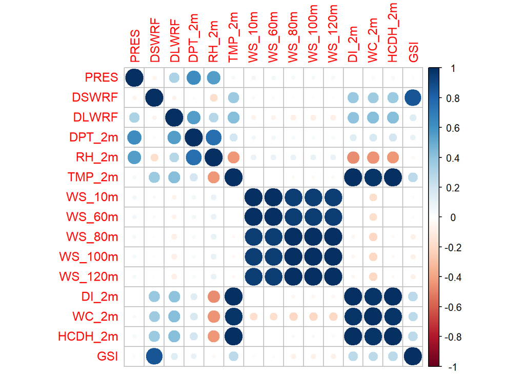

```r
# build correlation matrix of numeric predictors, display as corrplot
# consider generation as numeric predictor
weather_cor = cor(only_weather)
corrplot(weather_cor, method = "circle")
```

Figure 4: Weather Parameters Correlation Matrix

A few key relationships jump out from the correlation plot above:

1. All Wind Speeds are strongly correlated (>0.8) to each other, especially Wind Speed at 10m & 60m and Wind Speed at 80m, 100m, and 120m.
2. Wind Speeds are not strongly correlated to any other predictors
3. Temperature, Discomfort Index, Wind Chill, and Heating Cooling Degree Hours are all highly correlated (>0.8) with each other, and slightly anti-correlated with Relative Humidity (~0.4)
4. GSI is strongly correlated (>0.6) to direct solar irradiance
5. Pressure, Dew Point, and Humidity are all loosely correlated

It could be reasonable to merge highly-correlated variables, producing a single Avg Wind Speed, and simply using Temperature instead of Temperature, Discomfort Index, Wind Chill, and Heating Cooling Degree Hours. This would eliminate 7 parameters!

### Spatial EDA

After filtering, the weather nodes I am using in my models are ~17 miles apart. Thus we can expect very significant correlation between locations throughout a given day, however, this is a distance over which weather may change in one node before it changes in another (at the hourly timestep).

I chose to make maps of Wind Speed at 60m, Direct Solar Irradiance, and Temperature, as these are the three parameters that I expect to be most predictive of Wind generation, Solar generation, and electricity consumption, respectively. As there are over 100 locations, it was not feasible to look at relationships individually. The following figures shown mean values for each location.

```r
mean_spatial_summary = all_weather_long %>%
  pivot_wider(names_from = parameter, values_from = value) %>%
  group_by(lon, lat) %>%
  summarise(Mean_Wind_Speed = mean(WS_60m),
            Mean_Direct_Solar_Irradiance = mean(DSWRF),
            Mean_Temperature = mean(TMP_2m))
```

[output not shown]

```r
mapview(mean_spatial_summary, xcol = "lon", ycol = "lat", zcol = "Mean_Wind_Speed", crs = 4269)
```

[interactive chart not shown]

Figure 5a: Wind Map

```r
mapview(mean_spatial_summary, xcol = "lon", ycol = "lat", zcol = "Mean_Direct_Solar_Irradiance", crs = 4269)
```

[interactive chart not shown]

Figure 5b: Direct Solar Irradiance Map

```r
mapview(mean_spatial_summary, xcol = "lon", ycol = "lat", zcol = "Mean_Temperature", crs = 4269)
```

[interactive chart not shown]

Figure 5c: Temperature Map

We see typical weather patterns in the data: higher wind speeds offshore and higher temperatures and irradiance as we move inland.

### All Parameters EDA

While making a corrplot of all 1695 predictors wouldn’t be feasible, I made a correlation matrix, filtered out values on the prime diagonal (which are all equal to 1 as they are showing the correlation between a given predictor and itself), and then counted how many values in the matrix were equal to 1.

```r
# correlation matrix for entire testing set
train_cor = cor(goleta_train)
# filter out prime diag
for (i in 1:sqrt(length(train_cor))) {
  train_cor[i,i] = 0
}
train_cor_df = data.frame(train_cor)
perfectly_corr = matrix(nrow = 0, ncol = 2)
perfectly_corr = data.frame(perfectly_corr)
colnames(perfectly_corr) = c("Param1", "Param2")
# build df of perfectly correlated predictors
for (i in 1:sqrt(length(train_cor))) {
  for (j in 1:sqrt(length(train_cor))) {
    if (train_cor_df[i,j] == 1) {
      new_perf = c(row.names(train_cor_df)[i], colnames(train_cor_df)[j])
      perfectly_corr = rbind(perfectly_corr, new_perf)
    }
  }
}
```

There were 554 values in the matrix equal to 1, implying 277 instances of perfectly correlated predictors, as the matrix is mirrored. There were 0 instances of perfectly anti-correlated predictors. I then gathered all pairs of perfectly correlated predictors into a dataframe. In examining the predictors, I noticed that all perfect correlations fell into one of two categories:

1. Temperature (TMP_2m) and Heating Cooling Degree Hour (HCDH_2m) at a shared location
2. GSI at neighboring locations

As simple linear regressions will fail with perfectly correlated predictors, I decided to run two seperate ensembles of models:

1. Using all 15 predictor variables
2. Using only 7 predicors, having removed those that had perfect correlations in the data or were very strongly correlated (>0.9) to other parameters. This second dataset included only:

| Parameter | ID | Unit |
| --- | --- | --- |
| Pressure | PRES | pa |
| Direct Solar Irradiance | DSWRF | W/m2 |
| Diffuse Solar Irradiance | DLWRF | W/m2 |
| Dew Point (2m) | DPT_2m | K |
| Relative Humidity (2m) | RH_2m | % |
| Temperature (2m) | TMP_2m | K |
| Wind Speed (80m) | WS_80m | m/s |

I chose to use Wind Speed at 80m as it was closest to a median value.

```r
# select all predictors - GSI, HCDH
all_model_data_2 = all_model_data %>%
  select(-date) %>%
  select(-starts_with("GSI")) %>%
  select(-starts_with("HCDH"))%>%
  select(-starts_with("DI"))%>%
  select(-starts_with("WC"))%>%
  select(-starts_with("WS_10"))%>%
  select(-starts_with("WS_60"))%>%
  select(-starts_with("WS_100"))%>%
  select(-starts_with("WS_120"))
# check correlations, should be 0
cor_2 = cor(all_model_data_2)
for (i in 1:sqrt(length(cor_2))) {
  cor_2[i,i] = 0
}
sum(cor_2 == 1)
```

```
## [1] 0
```

As expected, the new data set has 0 perfectly correlated predictors! This dataset includes the same 25,258 observations, but only 793 predictor variables (7 parameters, 113 locations).

The modeling for this data set will take place in *Machine Learning Models Part 2*

# Machine Learning Models

I considered four types of models, with tuning parameters: *simple linear regression*, *tuned regularized regression*, *random forest regression*, and *boosted tree regression*. Table 2 summarizes the parameters being tuned for each model.

Table 2: Models and Tuning Parameters

Model

Tuning Parameters

Simple Linear Regression

None

Regularized Regression

- **penalty**: how much the model performance is punished for each additional parameters
- **mixture**: the ratio of Ridge to Lasso regularization

Random Forest

- **mtry:** the number of predictors that will be sampled at each split when building trees
- **trees:** total number of trees in the random forest
- **min_n:** smallest allowable node size

Boosted Tree

- **trees:** total number of trees

### Persistence Model

A simple model that predicts each LMP as the LMP of the previous day at the same hour.

```r
goleta_persistence = goleta_train %>%
  select(lmp, prev_day_lmp)
# calculate R2 of persistence model
goleta_persistence_rmse = metric_set(rmse)
goleta_persistence_rmse = goleta_persistence_rmse(goleta_persistence, truth = lmp,
                estimate = prev_day_lmp)
```

The persistence model has an RMSE of 16.39 when applied to the training dataset. We will use this when calculating the forecasting skill of our other models.

### Create Model Recipe

A simple recipe, modeling LMP as a function of all predictors. Predictors are centered and scaled.

```r
# generate recipe to predict LMP
goleta_recipe <- recipe(lmp ~ ., data = goleta_train) %>%
  # center and scale predictors
  step_center(all_predictors()) %>%
  step_scale(all_predictors())
```

### Simple Linear Regression

A classical linear regression, included to demonstrate how such a model will run astray when trying to model data with highly correlated predictors and many parameters relative to the total number of observations.

1 model

```r
goleta_lm_model <- linear_reg() %>%
  set_engine("lm")

goleta_lm_wflow <- workflow() %>%
  add_model(goleta_lm_model) %>%
  add_recipe(goleta_recipe)

goleta_lm_fit <- fit(goleta_lm_wflow, goleta_train)

goleta_train_res <- predict(goleta_lm_fit, new_data = goleta_train %>% select(-lmp))
goleta_train_res <- bind_cols(goleta_train_res, goleta_train %>% select(lmp))
goleta_lm_rmse = rmse(goleta_train_res, truth = lmp, estimate = .pred)
```

### Regularization Model tuning *penalty*, *mixture*

A regularized regression model finding the best values for penalty and mixture.

3 folds x 10 penalties x 6 mixtures = 180 models fit

```r
# set up model tuning penalty, mixture
goleta_reg_model <- linear_reg(penalty = tune(), mixture = tune()) %>%
  set_mode("regression") %>%
  set_engine("glmnet")
# build grid of tuning values
goleta_reg_grid <- grid_regular(penalty(range = c(0, 2)), mixture(range = c(0, 0.25)), levels = c(penalty = 10, mixture = 6))
# set up workflow with tuning model
goleta_reg_wf <- workflow() %>%
  add_model(goleta_reg_model) %>%
  add_recipe(goleta_recipe)
```

```
# tune models with folds, grid 5*10*6 = 300 models total
goleta_tune_regularization <- tune_grid(
  goleta_reg_wf,
  resamples = goleta_folds,
  grid = goleta_reg_grid
)
# save goleta_tune_regularization
saveRDS(goleta_tune_regularization, file = here("outputs", "goleta_tune_regularization.rds"))
```

```r
goleta_tune_regularization = readRDS(file = here("outputs", "goleta_tune_regularization.rds"))
```

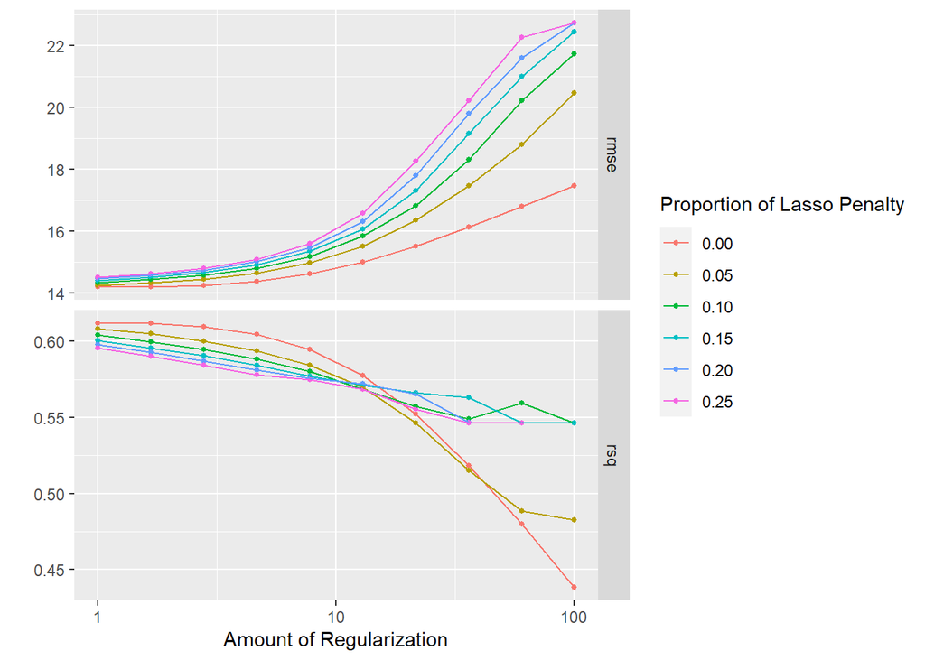

```r
# display model results
autoplot(goleta_tune_regularization)
```

```r
goleta_reg_metrics = collect_metrics(goleta_tune_regularization) %>% filter(.metric == "rmse") %>% arrange(mean)

goleta_reg_best_rmse = goleta_reg_metrics$mean[1]

goleta_reg_best_params <- select_best(goleta_tune_regularization, metric = "rmse")
```

### Random Forest Model tuning *mtry*, *trees*, *min_n* (3 folds x 1 mtry x 1 trees x 1 min_n = 3 models total)

A random forest regression model finding the best values for mtry, trees, and min_n.

I was unable to run the tuned random forest fit that I was hoping to, with mtry in [10, 100], trees in [100, 1000], and min_n in [5, 50]. This, however, would have taken over 36 hours to exectue (I halted the fitting after the 36 hours). Instead, I fit a range of models for smaller values of mtry, trees, and min_n to spot trends, and then ran individual models for larger values. The trends I noticed for the smaller values were:

1. models with more predictors performed better
2. models with more trees performed better
3. models with a smaller minimum node size performed better

I then expanded on these trends, reaching this final model. This model performed best of all random forests I tested, and took ~1.5 hours to run by itself.

```r
goleta_forest_model <- rand_forest(mtry = tune(), trees = tune(), min_n = tune()) %>%
  set_engine("ranger", importance = "impurity") %>%
  set_mode("regression")

goleta_forest_wf = workflow() %>%
  add_model(goleta_forest_model) %>%
  add_recipe(goleta_recipe)

goleta_param_grid_forest <- grid_regular(mtry(range = c(75,75)), trees(range = c(750,750)), min_n(range = c(10,10)), levels = c(mtry = 1, trees = 1, min_n = 1))
```

```
goleta_tune_res_forest <- tune_grid(
  goleta_forest_wf,
  resamples = goleta_folds,
  grid = goleta_param_grid_forest,
  metrics = metric_set(rmse)
)

saveRDS(goleta_tune_res_forest, file = here("outputs", "goleta_tune_res_forest.rds"))
```

```r
goleta_tune_res_forest = readRDS(file = here("outputs", "goleta_tune_res_forest.rds"))
```

```r
goleta_forest_metrics = collect_metrics(goleta_tune_res_forest, metric = "rmse") %>% arrange(mean)

goleta_forest_best_rmse = goleta_forest_metrics$mean[1]

goleta_forest_best_params <- select_best(goleta_tune_res_forest, metric = "rmse")
```